# Lab 11 Homework

2022-03-02

## Instructions

Answer the following questions and complete the exercises in RMarkdown. Please embed all of your code and push your final work to your repository. Your final lab report should be organized, clean, and run free from errors. Remember, you must remove the `#` for the included code chunks to run. Be sure to add your name to the author header above. For any included plots, make sure they are clearly labeled. You are free to use any plot type that you feel best communicates the results of your analysis.

**In this homework, you should make use of the aesthetics you have learned. It’s OK to be flashy!**

Make sure to use the formatting conventions of RMarkdown to make your report neat and clean!

## Load the libraries

```r
library(tidyverse)
library(janitor)
library(here)
library(naniar)
```

## Resources

The idea for this assignment came from [Rebecca Barter’s](http://www.rebeccabarter.com/blog/2017-11-17-ggplot2_tutorial/) ggplot tutorial so if you get stuck this is a good place to have a look.

## Gapminder

For this assignment, we are going to use the dataset [gapminder](https://cran.r-project.org/web/packages/gapminder/index.html). Gapminder includes information about economics, population, and life expectancy from countries all over the world. You will need to install it before use. This is the same data that we will use for midterm 2 so this is good practice.

```r
library(gapminder)
names(gapminder)
```

```
## [1] "country"   "continent" "year"      "lifeExp"   "pop"       "gdpPercap"
```

## Questions

The questions below are open-ended and have many possible solutions. Your approach should, where appropriate, include numerical summaries and visuals. Be creative; assume you are building an analysis that you would ultimately present to an audience of stakeholders. Feel free to try out different `geoms` if they more clearly present your results.

**1. Use the function(s) of your choice to get an idea of the overall structure of the data frame, including its dimensions, column names, variable classes, etc. As part of this, determine how NA’s are treated in the data.**

```r
glimpse(gapminder)
```

```
## Rows: 1,704
## Columns: 6
## $ country   <fct> "Afghanistan", "Afghanistan", "Afghanistan", "Afghanistan", …
## $ continent <fct> Asia, Asia, Asia, Asia, Asia, Asia, Asia, Asia, Asia, Asia, …
## $ year      <int> 1952, 1957, 1962, 1967, 1972, 1977, 1982, 1987, 1992, 1997, …
## $ lifeExp   <dbl> 28.801, 30.332, 31.997, 34.020, 36.088, 38.438, 39.854, 40.8…
## $ pop       <int> 8425333, 9240934, 10267083, 11537966, 13079460, 14880372, 12…
## $ gdpPercap <dbl> 779.4453, 820.8530, 853.1007, 836.1971, 739.9811, 786.1134, …
```

```r
is.na(gapminder)
```

[output not shown]

[output cut: 1690 more lines]

**2. Among the interesting variables in gapminder is life expectancy. How has global life expectancy changed between 1952 and 2007?**

```r
gapminder %>%
  filter(between(year, 1952, 2007)) %>%
  summarise(min=min(lifeExp),
            mean=mean(lifeExp),
            max=max(lifeExp))
```

```
## # A tibble: 1 × 3
##     min  mean   max
##   <dbl> <dbl> <dbl>
## 1  23.6  59.5  82.6
```

**3. How do the distributions of life expectancy compare for the years 1952 and 2007?**

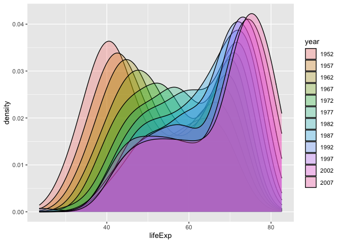

```r
gapminder %>%
  filter(between(year, 1952, 2007)) %>%
  mutate(year=as.factor(year)) %>%
  ggplot(aes(x=lifeExp, group=year, fill=year))+
  geom_density(alpha= 0.3)
```

**4. Your answer above doesn’t tell the whole story since life expectancy varies by region. Make a summary that shows the min, mean, and max life expectancy by continent for all years represented in the data.**

```r
gapminder %>%
  group_by(continent, year) %>%
  summarise(min=min(lifeExp),
            mean=mean(lifeExp),
            max=max(lifeExp))
```

```
## # A tibble: 60 × 5
## # Groups:   continent [5]
##    continent  year   min  mean   max
##    <fct>     <int> <dbl> <dbl> <dbl>
##  1 Africa     1952  30    39.1  52.7
##  2 Africa     1957  31.6  41.3  58.1
##  3 Africa     1962  32.8  43.3  60.2
##  4 Africa     1967  34.1  45.3  61.6
##  5 Africa     1972  35.4  47.5  64.3
##  6 Africa     1977  36.8  49.6  67.1
##  7 Africa     1982  38.4  51.6  69.9
##  8 Africa     1987  39.9  53.3  71.9
##  9 Africa     1992  23.6  53.6  73.6
## 10 Africa     1997  36.1  53.6  74.8
## # … with 50 more rows
```

**5. How has life expectancy changed between 1952-2007 for each continent?**

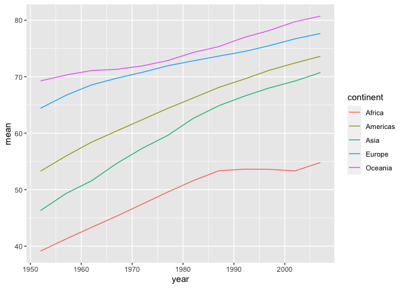

```r
gapminder %>%
  group_by(year, continent) %>%
  summarize(mean=mean(lifeExp)) %>%
  ggplot(aes(x=year, y=mean, group=continent, color=continent))+
  geom_line()
```

**6. We are interested in the relationship between per capita GDP and life expectancy; i.e. does having more money help you live longer?**

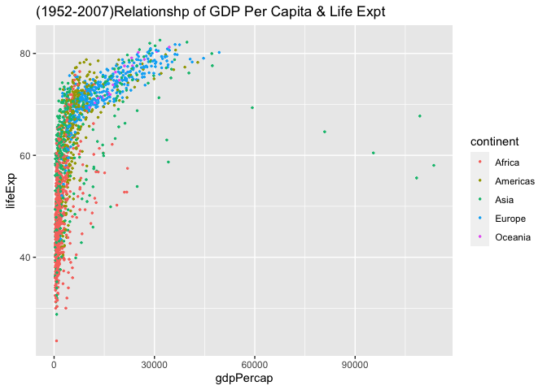

```r
gapminder %>%
  group_by(continent) %>%
  ggplot(aes(x=gdpPercap, y=lifeExp,
             color=continent)) +
  geom_point(size=0.5) +labs(title = "(1952-2007)Relationshp of GDP Per Capita & Life Expt")
```

**7. Which countries have had the largest population growth since 1952?**

```r
gapminder %>%
  select(year, country, pop) %>%
  filter(between(year, 1952, 2007)) %>%
  pivot_wider(names_from = year,
              names_prefix = "yr_",
              values_from = pop) %>%
  mutate(delta= yr_2007-yr_1952) %>%
  arrange(desc(delta))
```

```
## # A tibble: 142 × 14
##    country       yr_1952 yr_1957 yr_1962 yr_1967 yr_1972 yr_1977 yr_1982 yr_1987
##    <fct>           <int>   <int>   <int>   <int>   <int>   <int>   <int>   <int>
##  1 China          5.56e8  6.37e8  6.66e8  7.55e8  8.62e8  9.43e8  1.00e9  1.08e9
##  2 India          3.72e8  4.09e8  4.54e8  5.06e8  5.67e8  6.34e8  7.08e8  7.88e8
##  3 United States  1.58e8  1.72e8  1.87e8  1.99e8  2.10e8  2.20e8  2.32e8  2.43e8
##  4 Indonesia      8.21e7  9.01e7  9.90e7  1.09e8  1.21e8  1.37e8  1.53e8  1.69e8
##  5 Brazil         5.66e7  6.56e7  7.60e7  8.80e7  1.01e8  1.14e8  1.29e8  1.43e8
##  6 Pakistan       4.13e7  4.67e7  5.31e7  6.06e7  6.93e7  7.82e7  9.15e7  1.05e8
##  7 Bangladesh     4.69e7  5.14e7  5.68e7  6.28e7  7.08e7  8.04e7  9.31e7  1.04e8
##  8 Nigeria        3.31e7  3.72e7  4.19e7  4.73e7  5.37e7  6.22e7  7.30e7  8.16e7
##  9 Mexico         3.01e7  3.50e7  4.11e7  4.80e7  5.60e7  6.38e7  7.16e7  8.01e7
## 10 Philippines    2.24e7  2.61e7  3.03e7  3.54e7  4.09e7  4.69e7  5.35e7  6.00e7
## # … with 132 more rows, and 5 more variables: yr_1992 <int>, yr_1997 <int>,
## #   yr_2002 <int>, yr_2007 <int>, delta <int>
```

```r
 library(ggplot2)
 library(dplyr)
```

**8. Use your results from the question above to plot population growth for the top five countries since 1952.**

```r
gapminder %>%
  group_by(country) %>%
  filter(year==1952|year==2007) %>%
  summarise(pop)
```

```
## # A tibble: 284 × 2
## # Groups:   country [142]
##    country          pop
##    <fct>          <int>
##  1 Afghanistan  8425333
##  2 Afghanistan 31889923
##  3 Albania      1282697
##  4 Albania      3600523
##  5 Algeria      9279525
##  6 Algeria     33333216
##  7 Angola       4232095
##  8 Angola      12420476
##  9 Argentina   17876956
## 10 Argentina   40301927
## # … with 274 more rows
```

[figure not shown]

```r
 gapminder %>%
  filter(year==1952|year==2007) %>%
  group_by(country) %>%
  arrange(desc(pop)) %>%
  head(n=7) %>%
  ggplot(aes(x=country, y=pop, fill=country)) + geom_col() +
  theme(plot.title=element_text(hjust=0.5), axis.text.x = element_text(angle = 45, hjust=1))+
  labs(title="Population Growth Since 1952",
       x="Country",
       y="Population Growth")
```

#CHINA AND INDIA HAVE SEEN HUGE GROWTH SINCE 1952

[output not shown]

**9. How does per-capita GDP growth compare between these same five countries?**

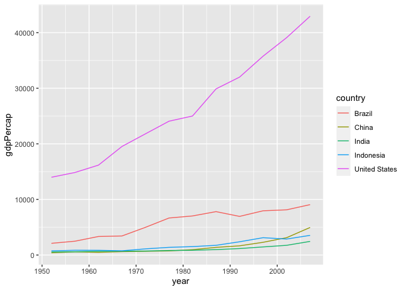

```r
gapminder %>%
  filter(country=="China" | country=="India" | country=="United States" | country=="Indonesia" | country=="Brazil") %>%
  select(year, country, gdpPercap) %>%
  ggplot(aes(x=year, y=gdpPercap, group=country, color=country))+
  geom_line()
```

**10. Make one plot of your choice that uses faceting!**

[figure not shown]

```r
gapminder %>%
  ggplot(aes(x=lifeExp))+geom_histogram()+facet_wrap(~year)+
  labs(title="Histogram of Life Expectancy [1952-2007]",
       x="Life Expectancy",
       y="Years")+
  theme(plot.title=element_text(hjust=1), axis.text.x = element_text(angle=25, hjust=1))
```

## Push your final code to GitHub!

Please be sure that you check the `keep md` file in the knit preferences.